# Draft assembly of Crepidostomum

Mar Llaberia-Robledillo

2023-05-11

## A short introduction

Our goal here is to get a first draft of the Crepidostomum genome. To do this, we have different types of data that we have previously processed:

- Nanopore Minion. We have done the basecalling: Ex68_3
- PacBio. Confused data: take a good look at it. According to Isa, she also got hold of two individuals of Crepidostomum, but they are not the same as those of Nanopore. And they are not parasites of Coregonus, but of Arctic charr.
- Illumina Shot Gun. Two compressed .fastq.gz files for Crepidostomum. A single individual: Ex71_6.

As for mount options, I have mainly two

2. Do two genome drafts: first with the Nanopore MinIon data and then with the PacBio data. In this way we could determine which are the data that present a better coverage and use them as a “base”.
3. Make a single genome draft with all the data, without distinction by individual. This is made possible by flye’s option to collapse the similar regions of haplotypes. Less optimal due to the loss of quality or accuracy of the genome draft.

So, first of all, flye is executed with the nanopore and pacbio rawdata, that is, to make a hybrid assembly of both types of long sequences. I will take the PacBio data as base first, and next, Nanopore data as base. Finally, a polish is done with the Illumina data.

# Assembly with FLYE

### Hybrid assembly with both PacBio and Nanopore

NOTE: flye: error: argument –pacbio-hifi: not allowed with argument –nano-hq Flye does not acceot the two arguments in the same run. Lucky for us, the author resolved this issue in his Github: https://github.com/fenderglass/Flye/issues/98

```bash
## Solution from the author in GitHub

#flye --pacbio-raw $PBREADS $ONTREADS --iterations 0 --out-dir $OUTPUTDIR  --genome-size 3.5g --threads $THREADS
#flye --pacbio-raw $PBREADS --resume-from polishing --out-dir $OUTPUTDIR  --genome-size 3.5g --threads $THREADS
```

```bash
if [ ! -d flye ]; then mkdir flye; fi

NANO="../2023-04-19/CRP/*.fastq"
PACBIO="../../data/PacBio/fastqs/demultiplex.bc1018_BAK8B_OA--bc1018_BAK8B_OA.hifi_reads.fastq.gz"

OUT="flye/PB_ONT"

if [ ! -d ./flye/PB_ONT ]; then
  flye --pacbio-raw $PACBIO $NANO -o $OUT -t 16 --iterations 0
  flye --pacbio-raw $PACBIO -o $OUT -t 16 --resume-from polishing
fi

OUT1="flye/ONT_PB"

if [ ! -d ./flye/ONT_PB ]; then
  flye --nano-raw $NANO $PACBIO -o $OUT1 -t 16 --iterations 0
  flye --nano-raw $NANO -o $OUT1 -t 16 --resume-from polishing
fi
```

## Assess draft genome quality (BUSCO)

We are going to asses the quality of the draft genomes, first for –pacbio-raw option as base and the other for –nano-raw option as base.

lineage that Jeremy uses: metazoa_odb10

```bash
DRAFT='flye/PB_ONT/assembly.fasta'

if [ ! -d pacbio ]; then
  busco -i $DRAFT -l metazoa_odb10 -o pacbio -m genome --cpu 16
fi

DRAFT1='flye/ONT_PB/assembly.fasta'
if [ ! -d nano ]; then
  busco -i $DRAFT1 -l metazoa_odb10 -o nano -m genome --cpu 16
fi
```

## Summaries

### Distribution of contig lengths

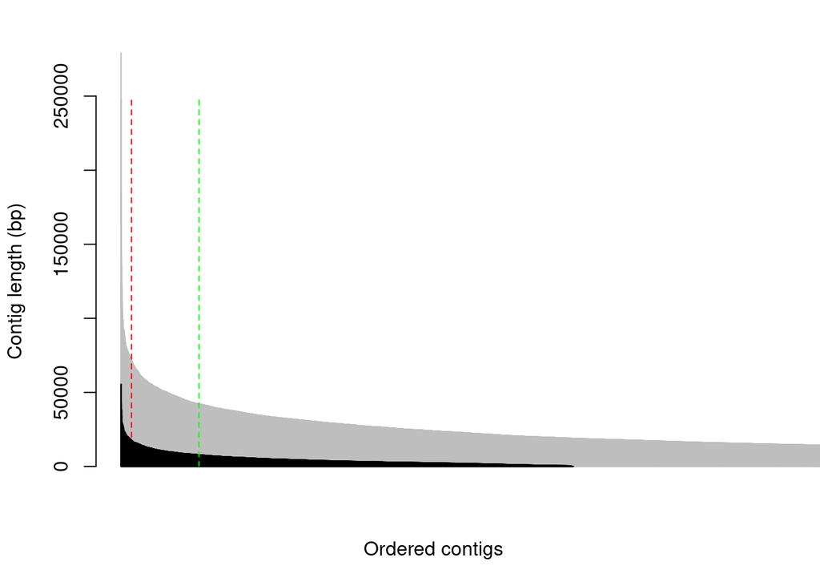

```r
nanoAssembly <- read.table('flye/ONT_PB/assembly_info.txt',
                           col.names = c('contig', 'length', 'cov', 'circ',
                                         'repeat', 'mult', 'skip', 'skip'),
                           colClasses = c('character', 'numeric', 'numeric',
                                          'factor', 'factor', 'numeric',
                                          'NULL', 'NULL'))
pacbioAssembly <- read.table('flye/PB_ONT/assembly_info.txt',
                             col.names = c('contig', 'length', 'cov', 'circ',
                                           'repeat', 'mult', 'skip', 'skip'),
                             colClasses = c('character', 'numeric', 'numeric',
                                            'factor', 'factor', 'numeric',
                                            'NULL', 'NULL'))
stopifnot(! is.unsorted(rev(pacbioAssembly$length)))
stopifnot(! is.unsorted(rev(nanoAssembly$length)))
nanoAssembly$sum <- cumsum(nanoAssembly$length)
pacbioAssembly$sum <- cumsum(pacbioAssembly$length)
nanoSize <- sum(pacbioAssembly$length)
pacbioSize <- sum(pacbioAssembly$length)
nanoN50  <- which(nanoAssembly$sum >= 0.5 * nanoSize)[1]
pacbioN50 <- which(pacbioAssembly$sum >= 0.5 * pacbioSize)[1]
barplot(nanoAssembly$length, col = 'gray', border = 'gray',
        xlim = c(1,7000), ylim = c(0, 250000),
        xlab = 'Ordered contigs', ylab = 'Contig length (bp)')
abline(v = nanoN50, col = 'red', lty = 2)
par(new = TRUE)
barplot(pacbioAssembly$length, col = 'black', axes = FALSE,
        xlim = c(1,7000), ylim = c(0, 250000),)
abline(v = pacbioN50, col = 'green', lty = 2)
```

The decreasingly ordered lengths of contigs of both assemblies suggest that the assembly made with Oxford Nanopore data (in gray above) is much better: contigs and total assembly length are much longer than in the PacBio assembly.

### *Peaks* of coverage depth

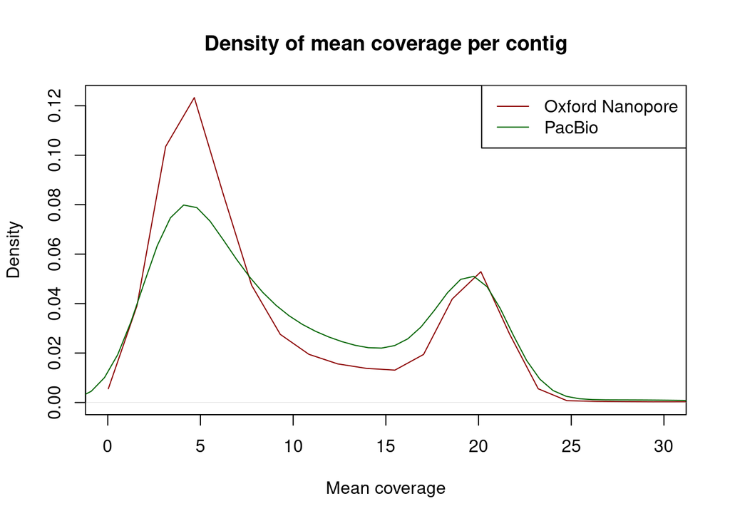

```r
plot(density(nanoAssembly$cov), xlim = c(0, 30), col = 'darkred',
     main = 'Density of mean coverage per contig',
     xlab = 'Mean coverage', ylab = 'Density')
lines(density(pacbioAssembly$cov), col = 'darkgreen')
legend('topright', col = c('darkred','darkgreen'), lty=1,
       legend = c('Oxford Nanopore', 'PacBio'))
```

Both assemblies show two peaks of coverage depth, at almost 5 and at almost 20. Approximately 34% of contigs, but less than 15% of the assembly length, seem to be represented over 4 times more than most of the genome. A factor of 4 in coverage differences among genome portions does not have an obvious explanation. The *octoploid* fraction has a slightly higher GC content (not shown), possibly indicating a different nature (just “repetitive”) of those sequences. But, the overlap in GC content distributions of the two genomic components is large. By the way, Petkevičiūtė and Stanevičiūtė (2008) shows a species of *Crepidostomum* has 6 pairs of chromosomes ($n=6$).

Contigs with a mean coverage higher than 25 should probably be excluded from any analysis.

### BUSCO analysis

```r
write.table(nanoAssembly[nanoAssembly$cov > 25, 'contig'],
            file = 'overcovered_contigs.txt', row.names = FALSE,
            col.names = FALSE, quote=FALSE)
```

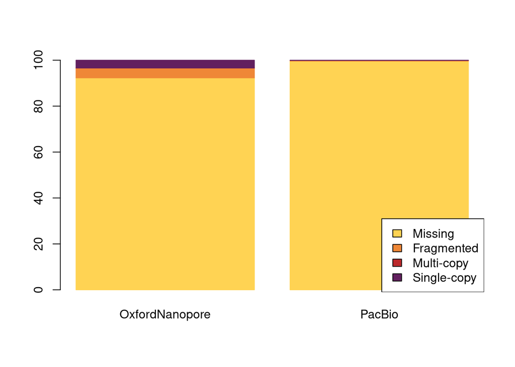

```r
library('jsonlite')
library('MetBrewer')
  nano <- fromJSON('nano/short_summary.specific.metazoa_odb10.nano.json')
pacbio <- fromJSON('pacbio/short_summary.specific.metazoa_odb10.pacbio.json')
busco  <- as.matrix(data.frame(
  OxfordNanopore = c(nano$results$Missing,
                     nano$results$Fragmented,
                     nano$results$'Multi copy',
                     nano$results$'Single copy'),
  PacBio = c(pacbio$results$Missing,
             pacbio$results$Fragmented,
             pacbio$results$'Multi copy',
             pacbio$results$'Single copy')
))
rownames(busco) <- c('Missing', 'Fragmented', 'Multi-copy', 'Single-copy')
pal <- met.brewer(name = 'Tam', n = 4, type = 'discrete')
barplot(busco, col = pal, border = pal)
legend('bottomright', fill = pal,
       legend = c('Missing', 'Fragmented', 'Multi-copy', 'Single-copy'))
```

BUSCO results confirm that the assembly made with Oxford Nanopore data first is a little better, in that at least a few of the expected genes were detected, either as single-copy or fragmented.

# Bibliography

Petkevičiūtė, R., and G. Stanevičiūtė. 2008. “Comparative karyological analysis of three members of Allocreadiidae (Digenea): taxonomic and phylogenetic implications.” *Parasitol. Res.* 103: 1105–10. https://doi.org/10.1007/s00436-008-1101-6.